# Week #13- Exponential Smoothing Methods

Cheng Peng

West Chester University

# 1 Introduction

Exponential smoothing methods are a family of algorithms that forecast future values by using exponentially decreasing weights of historical observations to forecast new values. Therefore as observations get older, the importance of these values diminishes exponentially. The more recent the observation the higher the associated weight. The exponentially decreasing weights are controlled by several smoothing coefficients based on the patterns of the underlying time series.

There are some obvious **advantages** of exponential smoothing methods:

- Exponential smoothing is very simple in concept and structure. It is also very easy to understand.
- Exponential smoothing is very powerful because of its exponentially-decayed weighting process.
- Exponential smoothing methods including Holt-Winters methods are appropriate for non-stationary data. In fact, they are only really appropriate if the data are non-stationary. Using an exponential smoothing method on stationary data is not wrong but is sub-optimal.
- Because exponential smoothing relies on only two pieces of data: (1). the last period’s actual value; (2). the forecast value for the same period. This minimizes the use of random access memory (RAM).
- Exponential smoothing requires minimum intervention in terms of model maintenance, it is can be adapted to make large-scale forecasting.

There are also **limitations** of exponential smoothing methods:

- The method is useful for short-term forecasting only. It assumes that future patterns and trends will not change significantly from the current patterns and trends. This kind of assumption may sound reasonable in the short term. However, it creates problems for the long-term forecast.
- Exponential smoothing will lag. In other words, the forecast will be behind, as the trend increases or decreases over time.
- Exponential smoothing will fail to account for the dynamic changes at work in the real world, and the forecast will constantly require updating to respond to new information.

To avoid getting bogged down in too much technical detail for various smoothing methods, we only outline the basic components in exponential smoothing models built on several reliable smoothing algorithms under the ETS framework in the following sections.

# 2 ETS Framework

The general exponential smoothing methods combine **error (E)**, **trend (T)**, and **seasonal(S)** components in such a way that the resulting functional forms and relevant smoothing coefficients best fit the historical data. **Each term** can be combined in one of three different ways: additive (**A**), multiplicative (**M**), and None (**N**). These three terms (**E**rror, **T**rend, and **S**eason) together with the ways of combinations are referred to as the **ETS** framework. **ETS** is also called the abbreviation of **E**xponen**T**ial **S**moothing.

The following table summarizes the possible ways to construct smoothing algorithms and forecasting models within the ETS framework.

| Error (E) | Trend (T) | Seasonality (S) |
| --- | --- | --- |
| Additive: **A** | Additive: **A** | Additive: **A** |
| Multiplicative: **M** | Multiplicative: **M** | Multiplicative: **M** |
|  | None: **N** | None: **N** |
|  | Additive Damped **Ad** |  |
|  | Multiplicative damped: **Md** |  |

## 2.1 Exponential Smoothing Methods

The idea of exponential smoothing is to smooth out the random fluctuations to see a clearer signal (trend and cycle, and seasonality). Depending on the pattern of the underlying time series, there are 15 different smoothing methods.

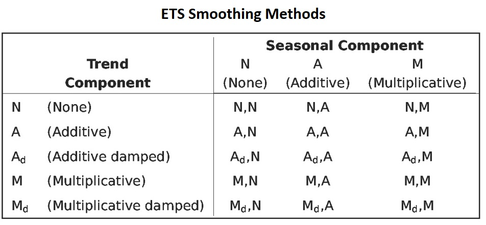

ETS smoothing methods

The patterns in different smoothing methods (except for the damped additive trend) are sketched in the following figure.

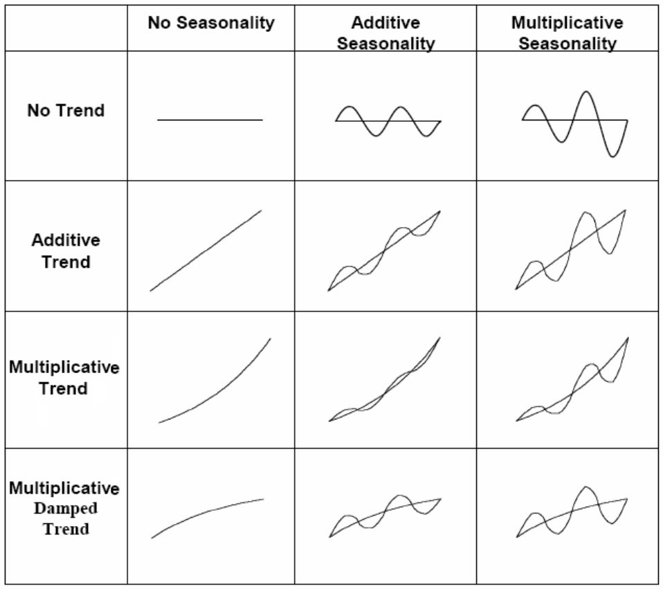

ETS smoothing charts

These patterns can be used in selecting specific smoothing models from the complete list of all possible models outlined in the following section.

## 2.2 Exponential Smoothing Models

The smoothing methods can only produce a point forecast. We can attach random error to the smoothing methods to build statistical forecast models. We can attach the error term to the combined trend and seasonality in the form of addition or multiplication. There are 30 exponential smoothing models.

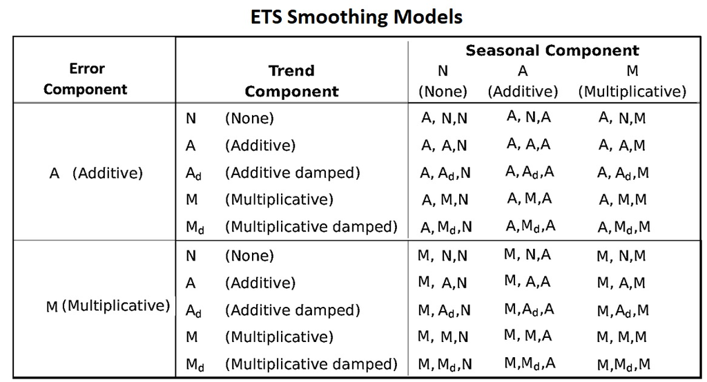

ETS smoothing models

We can use the notation **ETS(error, trend, seasonality)** to represent different smoothing models. For example, (1) **ETS(A,N,N)** - simple exponential smoothing model with additive errors, (2) **ETS(A,A,N)** - additive trend with additive errors (so Holt’s linear method with additive errors).

Since some of the ETS smoothing models are unstable, in this note, we only focus on a few commonly used smoothing models:

- **ETS(A,N,N)**: Simple exponential smoothing with additive errors.
- **ETS(A,A,N)**: Holt’s linear method with additive errors.
- **ETS(A,A,A)**: Additive Holt-Winters’ method with additive errors.
- **ETS(M,A,M)**: Multiplicative Holt-Winters’ method with multiplicative errors.
- **ETS(A,$A_d$,N)**: Damped trend method with additive errors.

## 2.3 Estimation Smoothing Parameters in Smoothing Models

There are different ways to estimate the coefficient of the smoothing parameter. One way is to find the smoothing parameters by minimizing the means square error (MSE). This is similar to the least square method. This is a distribution-free method and can be used to automate the exponential smoothing models.

The other method is the **likelihood** approach. After we include a random error with specific parametric distribution, we can estimate the coefficient parameters by using the likelihood method. We will not discuss estimation methods in detail.

Most of the smoothing models are implemented in the R library **forecast**. We will use this library to perform data analysis in this note.